# Discrete Movement Models

# Multi-state Random Walk

Animals often switch between behavioral states (e.g., resting, foraging, traveling). We can model this using a Multi-state Random Walk where movement parameters depend on the behavioral state.

## Markov Chains for State Transitions

First, we need to understand how to model state transitions using Markov chains. A Markov chain describes transitions between discrete states with fixed probabilities. We represent this with a **transition probability matrix** where element $M_{ij}$ is the probability of transitioning from state $i$ to state $j$. The matrix has the structure:

$$\mathbf{M} = \begin{bmatrix}
p_{11} & p_{12} & p_{13} \\
p_{21} & p_{22} & p_{23} \\
p_{31} & p_{32} & p_{33}
\end{bmatrix}$$

where each element $p_{ij} = P(X_{t+1} = j \mid X_t = i)$ represents the probability of transitioning from state $i$ to state $j$.

Note: because each row represents transition probabilities, their entries MUST sum to 1

$$\sum_{j=1}^{3} p_{ij} = 1 \quad
\text{for all } i$$

If $\boldsymbol{\pi}_t$ is a vector (list of numbers) representing the probability distribution over states at time $t$:

$$\boldsymbol{\pi}_t = [\pi_1(t),
\pi_2(t), \pi_3(t)]$$

then the distribution at the next time step is given by multiplying that vector my the transition matrix:

$$\boldsymbol{\pi}_{t+1} =
\boldsymbol{\pi}_t \mathbf{M}$$

In component form:

$$\pi_j(t+1) = \sum_{i=1}^{3} \pi_i(t)
\cdot p_{ij}$$

This says: the probability of being in state $j$ at time $t+1$ equals the sum over all states $i$ of the probability of being in state $i$ at time $t$ times the probability of transitioning from $i$ to $j$.

**Example:** If we start with certainty in state 1, i.e., $\boldsymbol{\pi}_0 = [1, 0, 0]$:

$$\boldsymbol{\pi}_1 = [1, 0, 0]
\begin{bmatrix}
0.7 & 0.2 & 0.1 \\
0.4 & 0.4 & 0.2 \\
0.0 & 0.8 & 0.2
\end{bmatrix} = [0.7, 0.2, 0.1]$$

After one step, there’s a 70% chance of being in state 1, 20% in state 2, and 10% in state 3.

## Simulating a Markov Chain

First, we specify the transition matrix. We’ll have 3 states, which we call “*chilling*” (state 1), “*cruising*” (state 2), and “*huffing*” (state 3), with the same matrix we described above.

```r
M <- rbind(
  c(0.7, 0.2, 0.1),   # From chilling
  c(0.4, 0.4, 0.2),   # From cruising
  c(0.0, 0.8, 0.2)    # From huffing
)

rownames(M) <- colnames(M) <- c("chilling", "cruising", "huffing")
M
```

```
##          chilling cruising huffing
## chilling      0.7      0.2     0.1
## cruising      0.4      0.4     0.2
## huffing       0.0      0.8     0.2
```

Let’s verify this is a valid transition matrix (rows sum to 1):

```r
rowSums(M)
```

```
## chilling cruising  huffing
##        1        1        1
```

To simulate a sequence of states, at each time step you have to “sample” the transition probabilities *for the fiven state*. If you’re in staet 1, you sample from the first row of the matrix with the appropriate probabilities, if in row 2, you sample from the second row, etc:

```r
n <- 400
states <- 1:3
State_mc <- rep(NA, n)  # empty simulation vector
State_mc[1] <- 1  # Start in "chilling" state

for(i in 2:n) {
  State_mc[i] <- sample(states, size = 1, prob = M[State_mc[i-1], ])
}

# Show first 100 states
State_mc[1:100]
```

```
##   [1] 1 2 3 2 1 1 2 1 1 1 1 1 1 1 1 2 2 2 3 3 2 3 3 2 2 1 1 3 2 1 2 1 1 1 2 1 1
##  [38] 1 1 1 1 1 1 1 2 1 2 2 3 2 1 1 1 1 2 1 1 1 1 3 2 3 2 1 1 1 2 1 1 1 1 1 1 1
##  [75] 2 2 1 1 1 2 1 1 3 3 2 2 2 2 1 1 1 3 2 2 1 1 1 1 1 1
```

## Calculate Stationary Distribution

The stationary distribution tells us the long-run proportion of time in each state. Empirically you just count percentages of time spent in each state:

```r
table(State_mc) |> prop.table()
```

```
## State_mc
##      1      2      3
## 0.5225 0.3550 0.1225
```

$$M \times {\bf v} = \lambda \times{\bf
v}$$

which means: there is a set of numbers (e.g. a set of probabilities of being in a behavioral state), that - when you multiply the matrix magic to it - gives you the *same vector*, just multiplied by a factor.

## Simulate Multi-state Random Walk

Now we’ll create a full multi-state random walk where movement parameters depend on the behavioral state.

```r
# Movement parameters for each state
# State 1 (chilling): no persistence, small steps
# State 2 (cruising): medium persistence, medium steps
# State 3 (huffing): high persistence, large steps

rhos <- c(0, 0.5, 0.9)        # turning angle concentration
alphas <- c(1, 2, 5)          # Weibull shape for step length
betas <- c(0.5, 3, 8)         # Weibull scale for step length

# Helper function for wrapped Cauchy
rwc <- function(n, mu, rho) {
  ifelse(rho == 0,
         runif(length(rho == 0), 0, 2*pi),
         rcauchy(n, mu, -log(rho)) %% (2 * pi))
}

# Simulate turning angles based on state
thetas <- rwc(n, mu = 0, rho = rhos[State_mc])

# Simulate step lengths based on state
step_lengths <- rweibull(n, shape = alphas[State_mc], scale = betas[State_mc])

# Create movement path
S <- complex(arg = cumsum(thetas), modulus = step_lengths)
Z <- cumsum(S)
```

Visualize the multi-state random walk:

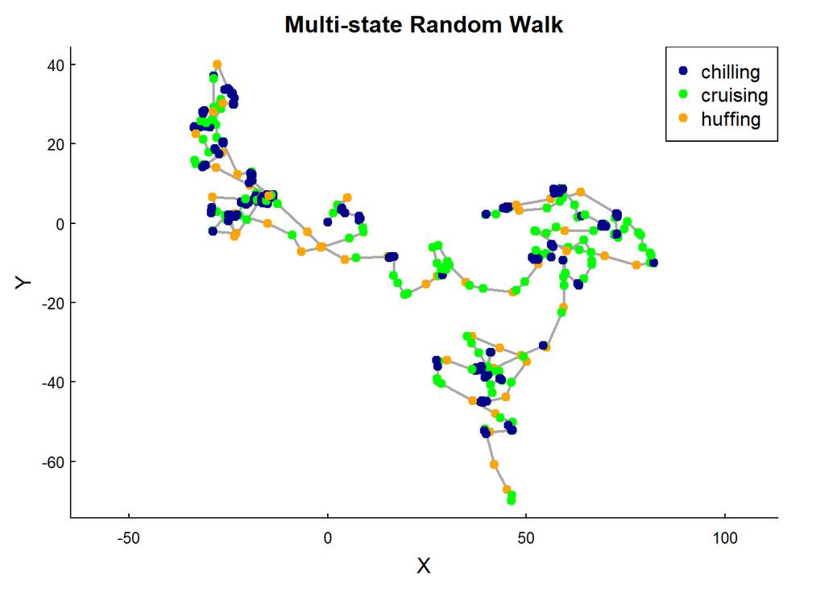

```r
pars()
cols <- c("darkblue", "green", "orange")
plot(Z, type = "l", col = "darkgrey", asp = 1, lwd = 2,
     main = "Multi-state Random Walk", xlab = "X", ylab = "Y")
points(Z, col = cols[State_mc], pch = 19)
legend("topright", legend = rownames(M), col = cols, pch = 19)
```

## Visualize State Sequence

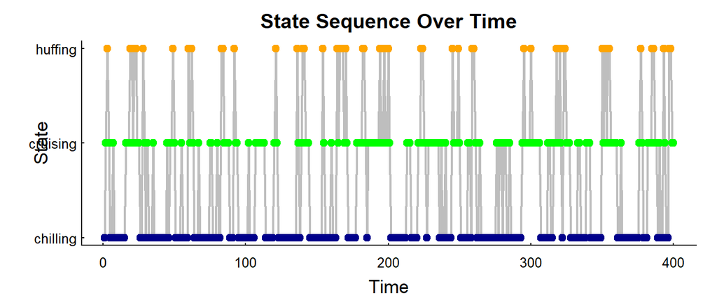

```r
pars()
par(mar = c(3, 4, 2, 1))
plot(1:n, State_mc, type = "l", lwd = 2, col = "grey",
     xlab = "Time", ylab = "State", yaxt = "n",
     main = "State Sequence Over Time")
points(1:n, State_mc, col = cols[State_mc], pch = 19)
axis(2, at = 1:3, labels = rownames(M), las = 1)
```

## Compare Movement Parameters Across States

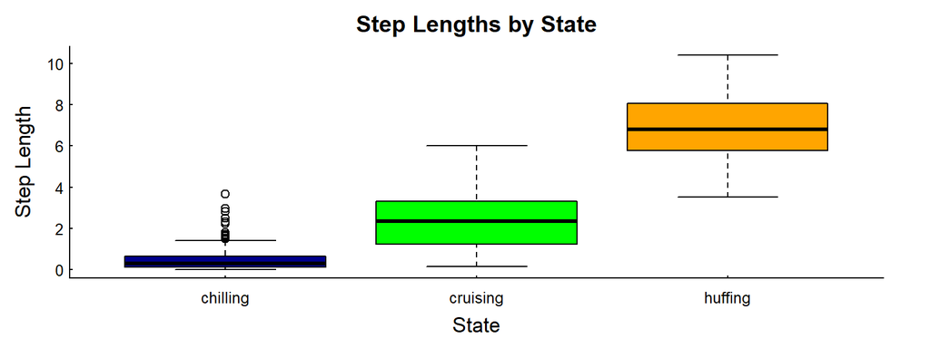

```r
boxplot(step_lengths ~ State_mc, col = cols,
        xlab = "State", ylab = "Step Length",
        names = rownames(M), main = "Step Lengths by State")
```

Note how I use a loop for the turning angles

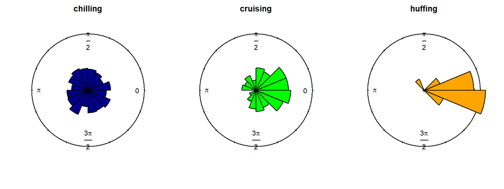

```r
require(circular)

for(i in 1:3)
rose.diag(thetas[State_mc == i], bins = 16, col = cols[i],
          prop = 1.5, main = rownames(M)[i])
```

# Exercises

1. **Random Walk Exploration**: Simulate 1D and 2D random walks with different $\sigma$ values. How does step size affect the area covered?
2. **AR Process Behavior**: Try different values of $\phi$ (e.g., 0.3, 0.6, 0.9). How does this affect the home range size? Verify the home range formula.
3. **CRW Persistence**: Modify the `rho` parameter in the CRW. What happens when rho = 0 (no directional persistence) vs rho = 0.95 (high persistence)?
4. **Multi-state Customization**: Create your own transition matrix and movement parameters. Try modeling different behaviors like:
   - Migration (directional state with long steps)
   - Foraging (slow, tortuous movement)
   - Resting (minimal movement)
5. **State Duration**: Calculate the average duration animals spend in each state. Hint: Look at run lengths of consecutive states.

# Summary

We’ve explored several fundamental movement models:

- **White Noise**: Uncorrelated, constrained, in a way the piece that everything else builds off.
- **Random Walks**: Unconstrained diffusion (walks to infinity)
- **Autoregressive Processes**: Spatially constrained, home-ranging behavior
- **Correlated Random Walks**: Directional persistence in movement
- **Multi-state Models**: Switching between behavioral states with different movement parameters